# Assignment_4

# Applying the Predict Function

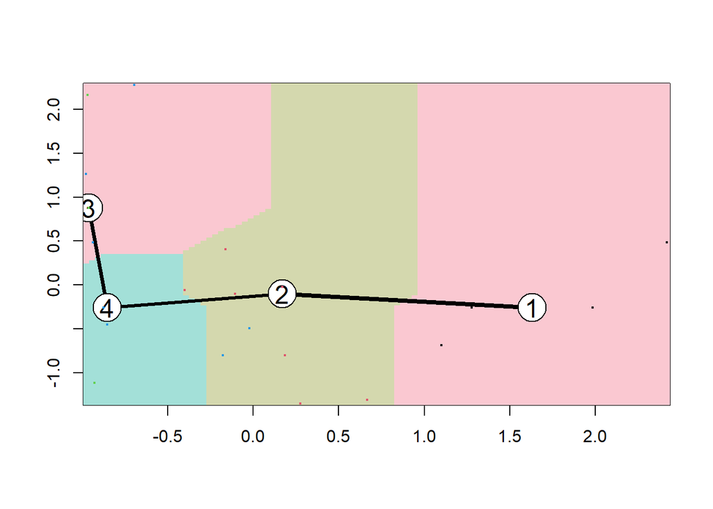

```r
set.seed(123)
clusters_index <- predict(k4)
image(k4)
points(N_Pharma, col=clusters_index, pch=19,cex=0.3)
```

```r
set.seed(123)
N_Pharma<- MPharma[ , c(3:11)]
```

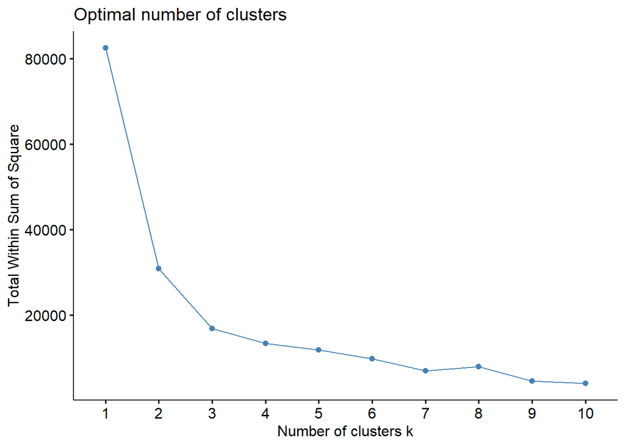

```r
set.seed(123)
fviz_nbclust(N_Pharma,kmeans,method = "wss")
```

#Interpretation of cluster : These interpretations provide insights into the characteristics of each cluster based on the average values of the numerical variables within each cluster.

```r
cluster_centers <- k4@centers
print(cluster_centers)
```

```
##      Market_Cap       Beta    PE_Ratio        ROE        ROA Asset_Turnover
## [1,]  1.6312072 -0.2559560 -0.25823657  1.1471522  1.3597391      1.1531640
## [2,]  0.1702742 -0.1001567 -0.24290879  0.1063815  0.5422849      0.0000000
## [3,] -0.9632863  0.8735889 -0.43297324 -0.9675348 -0.9610792     -1.8450624
## [4,] -0.8544181 -0.2559560  0.03299122 -0.7222576 -0.9047030     -0.4612656
##        Leverage Rev_Growth Net_Profit_Margin
## [1,] -0.4680782  0.5647048        0.57981316
## [2,] -0.2120979 -0.6481476        0.74744375
## [3,]  0.4406517  1.5386072       -0.09070919
## [4,] -0.3016910 -0.3811391       -1.24888417
```

# Is there a pattern in the clusters with respect to the numerical variables (10 to 12)? (those not used in forming the clusters).

To analyze if there’s a pattern in the clusters with respect to the numerical variables that were not used in forming the clusters (variables 10 to 12), we can examine the distribution of these variables across the clusters. While these variables were not directly used in forming the clusters, they can still provide additional insights into the characteristics of the clusters.

We can visualize the distribution of variables 10 to 12 across the clusters using box plots or other appropriate plots. Let’s assume these variables are named Median_Recommendation, Location, and Exchange. Here’s how we can visualize the distribution of these variables across the clusters:

# Extracting variables 10 to 12

```r
additional_variables <- MPharma[, c("Median_Recommendation", "Location", "Exchange")]
View(additional_variables)
```

# Accessing the cluster assignments from the k4 object

```r
cluster_assignments <- k4@cluster

additional_variables$Cluster <- cluster_assignments
str(additional_variables)
```

```
## 'data.frame':    21 obs. of  4 variables:
##  $ Median_Recommendation: chr  "Moderate Buy" "Moderate Buy" "Strong Buy" "Moderate Sell" ...
##  $ Location             : chr  "US" "CANADA" "UK" "UK" ...
##  $ Exchange             : chr  "NYSE" "NYSE" "NYSE" "NYSE" ...
##  $ Cluster              : int  2 4 4 2 4 4 2 4 3 2 ...
```

```r
any(is.na(additional_variables))
```

```
## [1] FALSE
```

# Plotting Additional Variables

```r
# Check for any unusual values in Median_Recommendation
head(additional_variables$Median_Recommendation)
```

```
## [1] "Moderate Buy"  "Moderate Buy"  "Strong Buy"    "Moderate Sell"
## [5] "Moderate Buy"  "Hold"
```

```r
head(additional_variables$Location)
```

```
## [1] "US"      "CANADA"  "UK"      "UK"      "FRANCE"  "GERMANY"
```

```r
head(additional_variables$Exchange)
```

```
## [1] "NYSE" "NYSE" "NYSE" "NYSE" "NYSE" "NYSE"
```

```r
head(additional_variables$Cluster)
```

```
## [1] 2 4 4 2 4 4
```

# Creating boxplots using ggplot2

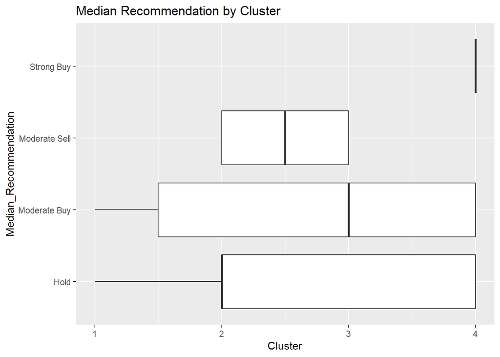

```r
# For Median_Recommendation
ggplot(additional_variables, aes(x = Cluster, y = Median_Recommendation)) +
  geom_boxplot() +
  labs(title = "Median Recommendation by Cluster")
```

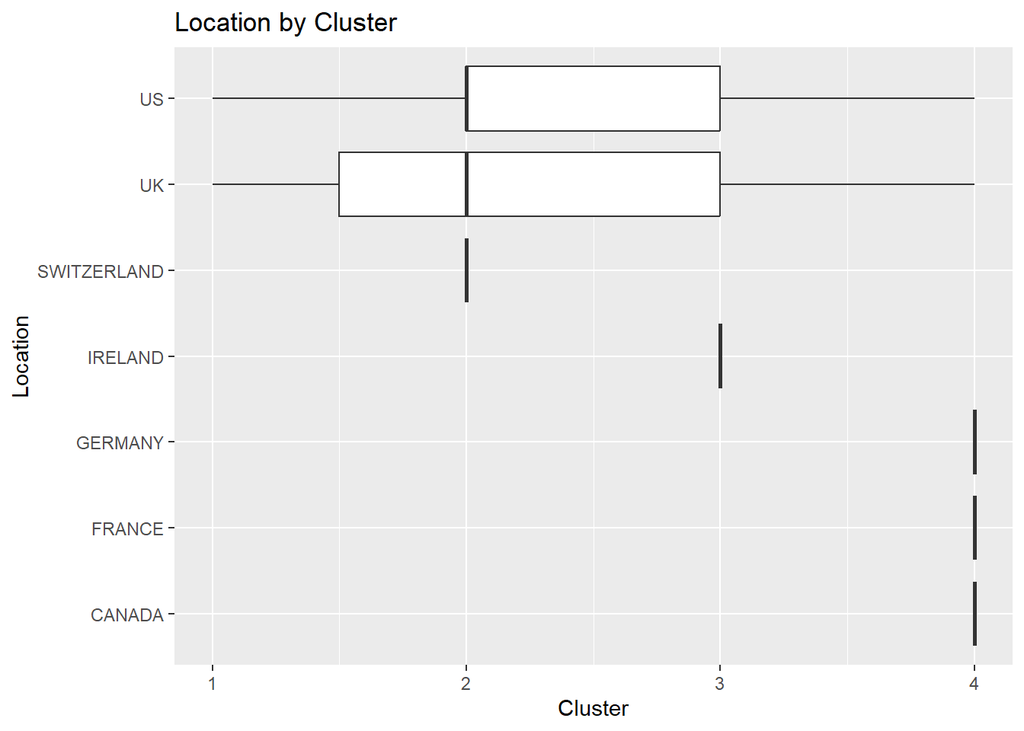

```r
# For Location
ggplot(additional_variables, aes(x = Cluster, y = Location)) +
  geom_boxplot() +
  labs(title = "Location by Cluster")
```

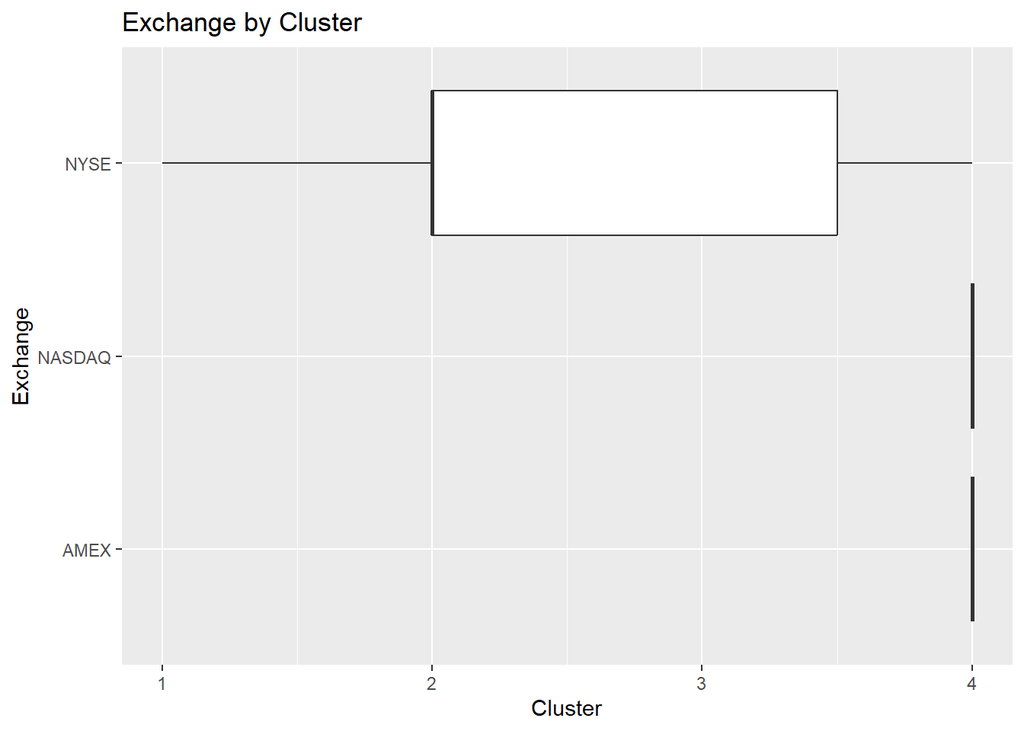

```r
# For Exchange
ggplot(additional_variables, aes(x = Cluster, y = Exchange)) +
  geom_boxplot() +
  labs(title = "Exchange by Cluster")
```

```r
str(additional_variables$Cluster)
```

```
##  int [1:21] 2 4 4 2 4 4 2 4 3 2 ...
```

```r
additional_variables$Cluster <- as.factor(additional_variables$Cluster)
any(is.na(additional_variables$Cluster))
```

```
## [1] FALSE
```

Ploting Boxplot for additional Varibles

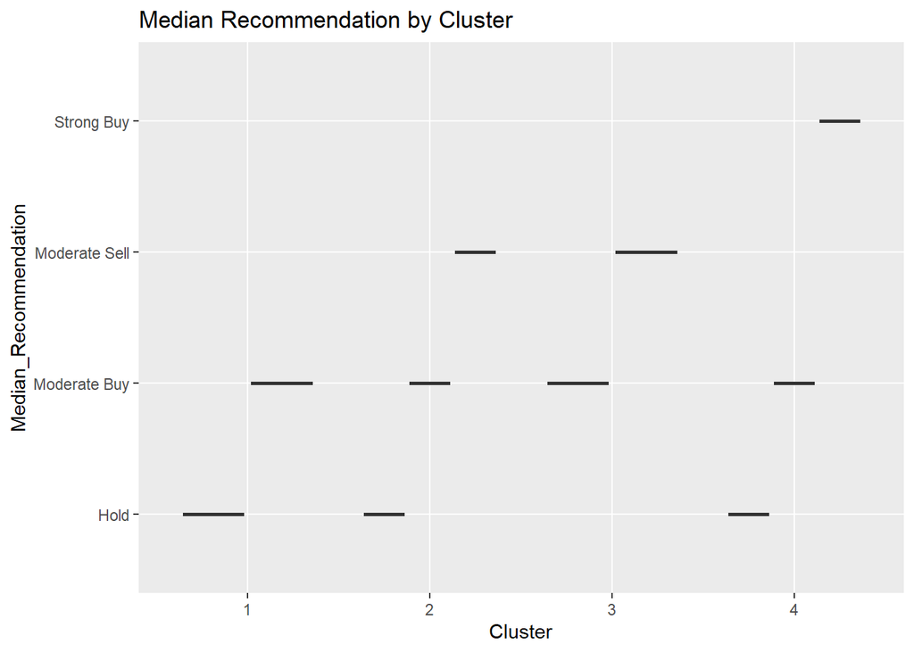

```r
# Plot the boxplot
ggplot(additional_variables, aes(x = Cluster, y = Median_Recommendation)) +
  geom_boxplot() +
  labs(title = "Median Recommendation by Cluster")
```

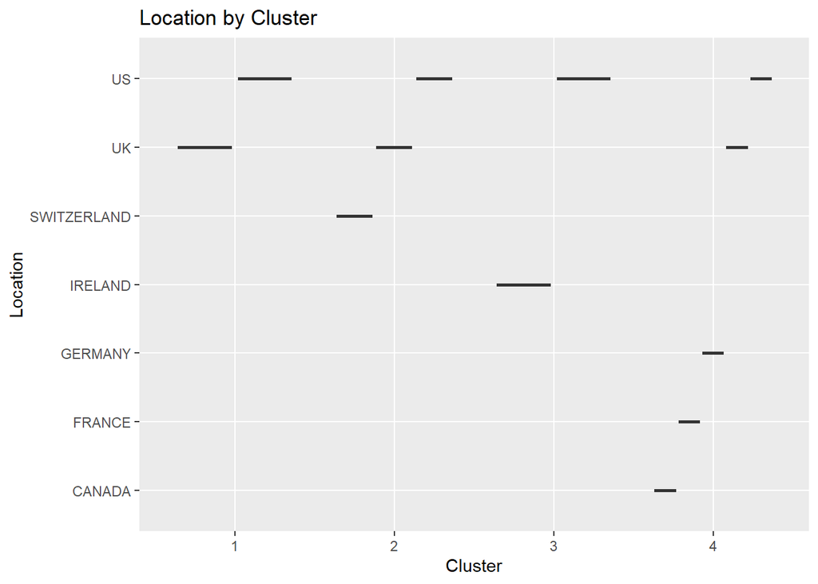

```r
# For Location
ggplot(additional_variables, aes(x = Cluster, y = Location)) +
  geom_boxplot() +
  labs(title = "Location by Cluster")
```

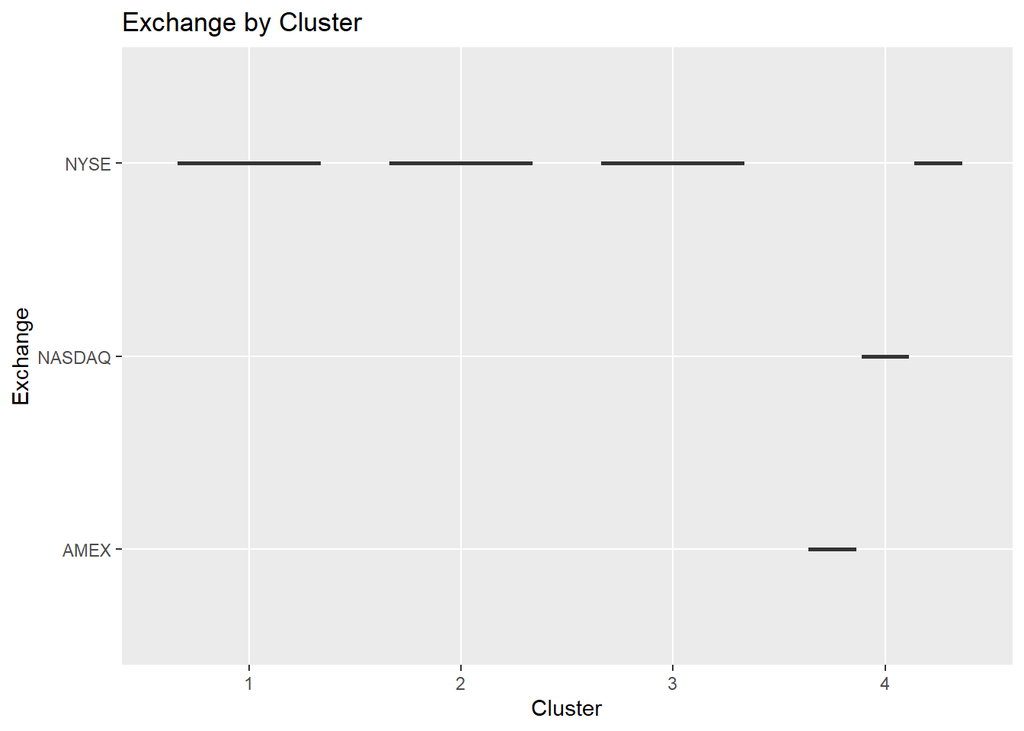

```r
# For Exchange
ggplot(additional_variables, aes(x = Cluster, y = Exchange)) +
  geom_boxplot() +
  labs(title = "Exchange by Cluster")
```

#d. Provide an appropriate name for each cluster using any or all of the variables in the dataset.

```r
# Defining appropriate names for the clusters
cluster_names <- c("Cluster 1: Below Perfomence",
                   "Cluster 2: Good Performance",
                   "Cluster 3: Top Performence",
                   "Cluster 4: Moderate Performance")
```

```r
# Adding cluster names to the dataset
MPharma_with_names <- mutate(MPharma, Cluster_Name = cluster_names[cluster_assignments])

head(MPharma_with_names)
```

```
##   Symbol                Name Market_Cap Beta PE_Ratio  ROE  ROA Asset_Turnover
## 1    ABT Abbott Laboratories      68.44 0.32     24.7 26.4 11.8            0.7
## 2    AGN      Allergan, Inc.       7.58 0.41     82.5 12.9  5.5            0.9
## 3    AHM        Amersham plc       6.30 0.46     20.7 14.9  7.8            0.9
## 4    AZN     AstraZeneca PLC      67.63 0.52     21.5 27.4 15.4            0.9
## 5    AVE             Aventis      47.16 0.32     20.1 21.8  7.5            0.6
## 6    BAY            Bayer AG      16.90 1.11     27.9  3.9  1.4            0.6
##   Leverage Rev_Growth Net_Profit_Margin Median_Recommendation Location Exchange
## 1     0.42       7.54              16.1          Moderate Buy       US     NYSE
## 2     0.60       9.16               5.5          Moderate Buy   CANADA     NYSE
## 3     0.27       7.05              11.2            Strong Buy       UK     NYSE
## 4     0.00      15.00              18.0         Moderate Sell       UK     NYSE
## 5     0.34      26.81              12.9          Moderate Buy   FRANCE     NYSE
## 6     0.00      -3.17               2.6                  Hold  GERMANY     NYSE
##                      Cluster_Name
## 1     Cluster 2: Good Performance
## 2 Cluster 4: Moderate Performance
## 3 Cluster 4: Moderate Performance
## 4     Cluster 2: Good Performance
## 5 Cluster 4: Moderate Performance
## 6 Cluster 4: Moderate Performance
```

```r
View(MPharma_with_names)
```